# Tarea 3

Jorge, Adrian, Carlos, Miguel y Alexa

2021

## Contexto

Rappi te contrata para hacer una intervención que active a sus usuarios en la plataforma. La empresa quiere evaluar si es necesario darles cash los usuarios (y cuánto) para reactivar a los usuarios o si es suficiente con una campaña informativa.

Para ello, te decides a realizar un experimento factorial donde evaluas:

- El impacto de mandar un mensaje informativo donde muestres las nuevas tiendas afiliadas a Rappi, y
- El impacto de dar 100 ó 200 pesos en cupones

Finalmente, les gustaría entender cómo interactuar el mostras las nuevas tiendas aunado con dar dinero en cupones.

A la empresa le gustaría entender el impacto de la intervención sobre:

- Las compras
- La tasa de usuarios activos en la app (transaccionar: abrir app o hacer compras)

## Datos

Los dotos para asignar los pueden encontrar en `universo.Rdata`.

Cargemos los datos

### 2 (2pts). Como pueden notar, tenemos 2 poblaciones: Usuarios inactivos y usuarios que nunca estuvieron activos. Para ellos, las tasas de transaccionalidad son hasta ahora 7.94% y 0%. Utiliza esta información para hacer pruebas de poder: Dada esta tasa y población, cuál es el efecto mínimo detectable sobre la tasa de transaccionalidad como función de cuantas observaciones asignamos al grupo control? Interpreta. (Tip: asegurate de dejar claros los grupos comparados en esta prueba)

```r
numero<-universo%>%
  group_by(population)%>%
  summarise(num=n())

n_control<-numero$num[2]
n_tratamiento<-numero$num[1]

universo<-universo%>%
mutate(tasa_trans=ifelse(population=="Never Active",0,0.0794))

tabla_taumin<-tau_min(outcome_var=universo$tasa_trans,N=length(universo$total_purchases),share_control=n_control/(n_control+n_tratamiento),n_groups = 2)

tabla_taumin%>%
  kbl(caption = "Tabla 1 del Efecto Mìnimo Detectable",align = 'c') %>%
  kable_classic(full_width = F, html_font = "Cambria")
```

Tabla 1 del Efecto Mìnimo Detectable

| share_control | share_ti | share_treat | N | N_control | N_treat | N_ti | tau_min_global | tau_min_each_treat |
| --- | --- | --- | --- | --- | --- | --- | --- | --- |
| 0.8648252 | 0.1351748 | 0.1351748 | 104191 | 90107 | 14084 | 14084 | 0.0006891 | 0.0006891 |

El efecto mínimo detectable es 0.0689% dadas las 90107 observaciones asignadas al grupo control. Esto quiere decir que, a partir de una diferencia de 0.0689% en la tasa de transaccionalidad podría ser significativo el efecto de tratamiento dados: i) el tamaño de la población 104191, ii) una proporción de 13.5% de los inidviduos asignados al grupo de tratamiento, iii) el poder estadístico de 0.8 y iv) una significacncia de 0.05.

### 3. Repite el mismo ejercicio pero ahora para usando las compras totales como variable objetivo. Elige un share de control con base en tu respuesta de esta y la anterior pregunta

```r
tab2_taumin<-tau_min(outcome_var=universo$total_purchases,N=length(universo$total_purchases),share_control=n_control/(n_control+n_tratamiento),n_groups = 2)

tab2_taumin%>%
  kbl(caption = "Tabla 2 del Efecto Mínimo Detectable",align = 'c') %>%
  kable_classic(full_width = F, html_font = "Cambria")
```

Tabla 2 del Efecto Mínimo Detectable

| share_control | share_ti | share_treat | N | N_control | N_treat | N_ti | tau_min_global | tau_min_each_treat |
| --- | --- | --- | --- | --- | --- | --- | --- | --- |
| 0.8648252 | 0.1351748 | 0.1351748 | 104191 | 90107 | 14084 | 14084 | 14.71244 | 14.71244 |

En esta ocasión el efecto mínimo detectable resultó 14.71, lo que implica que a partir de una diferencia de gasto de $14.71 entre los tratados y los no tratados, podríamos comenzar a observar un efecto de tratamiento significativo, bajo los mismos parámetros que en la pregunta anterior.

### 4 (2ptos) Qué variables crees que puedan estar más correlacionadas con el impacto? Justifica tu respuesta y elige un set

- Device value: Esta variable está correlacionada con el impacto ya que posiblemente tenga un mayor impacto en alguien que tiene un valor de dispositivo bajo ya que esta ayuda sería de mayor valor. Mientras que alguien que ya ha gastado mucho es menos probable que aumente ya que relativo al valor que gastan el monto de los cupones es muy bajo.

```r
universo%>%
  group_by(device_value)%>%
  summarise(media=mean(total_purchases))%>%
  kbl(caption = "Tabla: Compras promedio por gurpo de valor del dispositivo",align = 'c') %>%
  kable_classic(full_width = F, html_font = "Cambria")
```

Tabla: Compras promedio por gurpo de valor del dispositivo

| device_value | media |
| --- | --- |
| [$0-$10,000] | 72.48801 |
| [$10,001+] | 118.51310 |
| No info | 38.34254 |

- Edad: Es más probable que los individuos jóvenes tengan menores ingresos, por lo que un cupón es más probable que aumente sus compras en la aplicación. Por el otro lado, es más probable que la gentemayor se olvide de la aplicación por lo que un mensaje informativo podría aumentar sus compras.

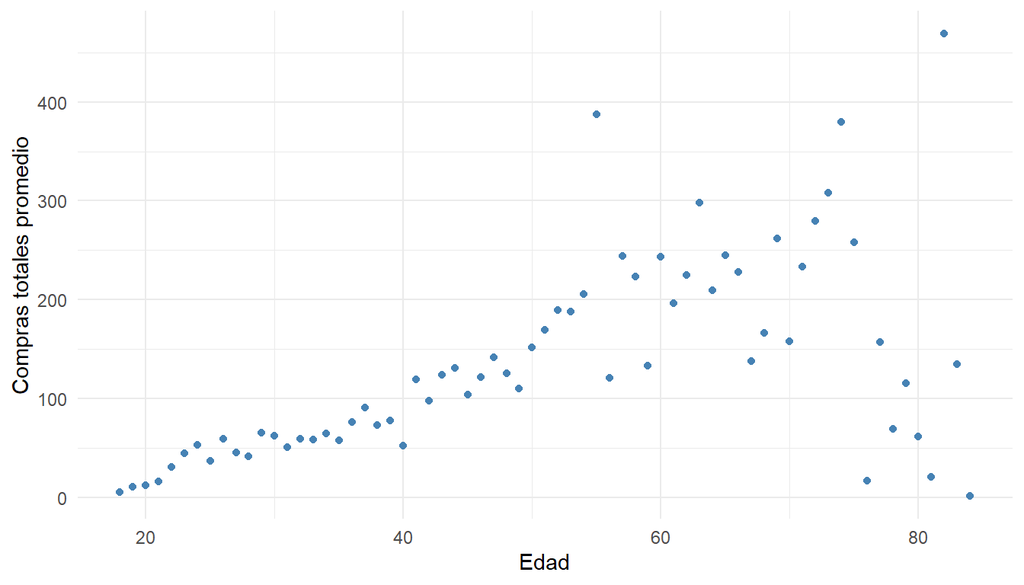

```r
edad<-universo%>%group_by(age)%>%summarise(media=mean(total_purchases))


ggplot(edad, aes(x=age,y=media))+
  geom_point(color="steelblue")+
  theme_minimal()+
  labs(x="Edad", y="Compras totales promedio")
```

- Gender: En la tabla a continuación se puede observar que los hombres gastan menos que las mujeres. Por lo tanto, darle un cupón o un recordatorio a los hombres podría tener mayor impacto.

```r
universo%>%
  group_by(gender_F)%>%
  summarise(media=mean(total_purchases))%>%
  kbl(caption = "Tabla: Compras promedio por génro",align = 'c') %>%
  kable_classic(full_width = F, html_font = "Cambria")
```

Tabla: Compras promedio por génro

| gender_F | media |
| --- | --- |
| 0 | 41.35113 |
| 1 | 94.44712 |

### 5 (2ptos) Realiza la asignación aleatoria. Muestra la distribución de los grupos por estrato, los misfits. Sin mirar el balance, lograron una asignación aleatoria exitosa? Justifica tu respuesta

```r
universo$device_value<-as.factor(universo$device_value)
universo$genero_cat<-as.factor(universo$gender_F)

aux<-summary(universo$age)
universo<-universo%>%
mutate(edad_cat=ifelse(age<=aux[2],1,ifelse(age>aux[2]&age<=aux[3],2,ifelse(age>aux[3]&age<=aux[5],3,4))))
universo$edad_cat<-as.factor(universo$edad_cat)

estratos<-treatment_assign(data = universo, share_control=0.5, n_t = 7, strata_varlist = dplyr::vars(device_value,genero_cat,edad_cat), missfits=c("NA"), key = "population")

estratos_sum<-estratos$data%>%
group_by(strata,treat)%>%
mutate(population=as.factor(population))%>%
summarise(n_pop=n())

estratos_sum%>%
  kbl(caption = "Tabla: Distribución de los grupos por estrato y tratamiento",align = 'c') %>%
  kable_classic(full_width = F, html_font = "Cambria")%>%
  footnote(general = "Los missfits son las observaciones que tienen NA en el tratamiento.")
```

Tabla: Distribución de los grupos por estrato y tratamiento

| strata | treat | n_pop |
| --- | --- | --- |
| 1 | 0 | 4158 |
| 1 | 1 | 594 |
| 1 | 2 | 593 |
| 1 | 3 | 595 |
| 1 | 4 | 594 |
| 1 | 5 | 594 |
| 1 | 6 | 594 |
| 1 | 7 | 594 |
| 1 | NA | 6 |
| 2 | 0 | 5264 |
| 2 | 1 | 752 |
| 2 | 2 | 751 |
| 2 | 3 | 753 |
| 2 | 4 | 752 |
| 2 | 5 | 752 |
| 2 | 6 | 752 |
| 2 | 7 | 752 |
| 2 | NA | 1 |
| 3 | 0 | 4319 |
| 3 | 1 | 617 |
| 3 | 2 | 616 |
| 3 | 3 | 618 |
| 3 | 4 | 617 |
| 3 | 5 | 617 |
| 3 | 6 | 617 |
| 3 | 7 | 617 |
| 3 | NA | 4 |
| 4 | 0 | 4431 |
| 4 | 1 | 633 |
| 4 | 2 | 632 |

[output cut: 141 more lines]

Note:  
Los missfits son las observaciones que tienen NA en el tratamiento.

```r
estratos_sum_missfit<-estratos$data%>%
group_by(strata,missfit)%>%
mutate(population=as.factor(population))%>%
summarise(n_pop=n())%>%
filter(missfit>=1)


estratos_sum_missfit_2<-estratos$summary_strata

estratos_sum_missfit_2%>%
  kbl(caption = "Tabla: Distribuciones de observaciones y misfits por grupos",align = 'c') %>%
  kable_classic(full_width = F, html_font = "Cambria")
```

Tabla: Distribuciones de observaciones y misfits por grupos

| strata | device_value | genero_cat | edad_cat | n_strata | n_missfits |
| --- | --- | --- | --- | --- | --- |
| 1 | [$0-$10,000] | 0 | 1 | 8322 | 6 |
| 2 | [$0-$10,000] | 0 | 2 | 10529 | 1 |
| 3 | [$0-$10,000] | 0 | 3 | 8642 | 4 |
| 4 | [$0-$10,000] | 0 | 4 | 8868 | 6 |
| 5 | [$0-$10,000] | 1 | 1 | 1623 | 13 |
| 6 | [$0-$10,000] | 1 | 2 | 3292 | 2 |
| 7 | [$0-$10,000] | 1 | 3 | 3319 | 1 |
| 8 | [$0-$10,000] | 1 | 4 | 5084 | 2 |
| 9 | [$10,001+] | 0 | 1 | 14 | 0 |
| 10 | [$10,001+] | 0 | 2 | 13 | 13 |
| 11 | [$10,001+] | 0 | 3 | 14 | 0 |
| 12 | [$10,001+] | 0 | 4 | 16 | 2 |
| 13 | [$10,001+] | 1 | 1 | 1 | 1 |
| 14 | [$10,001+] | 1 | 2 | 1 | 1 |
| 15 | [$10,001+] | 1 | 3 | 5 | 5 |
| 16 | [$10,001+] | 1 | 4 | 12 | 12 |
| 17 | No info | 0 | 1 | 14262 | 10 |
| 18 | No info | 0 | 2 | 11973 | 3 |
| 19 | No info | 0 | 3 | 7750 | 8 |
| 20 | No info | 0 | 4 | 7629 | 13 |
| 21 | No info | 1 | 1 | 2567 | 5 |
| 22 | No info | 1 | 2 | 3256 | 8 |
| 23 | No info | 1 | 3 | 2894 | 10 |
| 24 | No info | 1 | 4 | 4105 | 3 |

Así el número total de missfits es:

```r
sum(estratos_sum_missfit_2$n_missfits)
```

```
[1] 129
```

Es de esperar que se haya logrado una asignación aleatoria existosa ya que por construcción se asignó el tratamiento dentro de cada estrato de interés garantizando que las observaciones estarán balanceadas para esas variables.

### 7. Realiza las pruebas de balance t sobre todas las variables (Tip: transforma las categóricas en dummys). Parece haber balance?

```r
datos_universo<-left_join(estratos$data,estratos_sum_missfit_2,by=c("strata"))

datos_universo<-datos_universo%>%
filter(missfit != 1)%>%
dplyr::select(-n_strata,-n_missfits,-missfit)%>%
filter(strata != 13 | strata !=14)%>%
dummy_cols(select_columns=c("device_value","edad_cat"))%>%
dplyr::select(-edad_cat,-device_value,-population,-strata)%>%
mutate(genero_cat=as.numeric(genero_cat))

balance_table<-balance_table(data=datos_universo,treatment="treat")


balance_table%>%
  kbl(caption = "Tabla: Tabla de Balance",align = 'c', digits = 3) %>%
  kable_classic(full_width = F, html_font = "Cambria")
```

Tabla: Tabla de Balance

| variables1 | Media_control1 | Media_trat1 | Media_trat2 | Media_trat3 | Media_trat4 | Media_trat5 | Media_trat6 | Media_trat7 | p_value1 | p_value2 | p_value3 | p_value4 | p_value5 | p_value6 | p_value7 |
| --- | --- | --- | --- | --- | --- | --- | --- | --- | --- | --- | --- | --- | --- | --- | --- |
| device_value_[$0-$10,000] | 0.477 | 0.477 | 0.477 | 0.477 | 0.477 | 0.477 | 0.477 | 0.477 | 1 | 0.982 | 0.982 | 1 | 1 | 1 | 1 |
| device_value_[$10,001+] | 0.000 | 0.000 | 0.000 | 0.001 | 0.000 | 0.000 | 0.000 | 0.000 | 1 | 0.000 | 0.238 | 1 | 1 | 1 | 1 |
| device_value_No info | 0.523 | 0.523 | 0.523 | 0.522 | 0.523 | 0.523 | 0.523 | 0.523 | 1 | 0.967 | 0.967 | 1 | 1 | 1 | 1 |
| edad_cat_1 | 0.257 | 0.257 | 0.257 | 0.257 | 0.257 | 0.257 | 0.257 | 0.257 | 1 | 0.998 | 0.998 | 1 | 1 | 1 | 1 |
| edad_cat_2 | 0.279 | 0.279 | 0.279 | 0.279 | 0.279 | 0.279 | 0.279 | 0.279 | 1 | 0.975 | 0.975 | 1 | 1 | 1 | 1 |
| edad_cat_3 | 0.217 | 0.217 | 0.217 | 0.217 | 0.217 | 0.217 | 0.217 | 0.217 | 1 | 0.982 | 0.982 | 1 | 1 | 1 | 1 |
| edad_cat_4 | 0.247 | 0.247 | 0.247 | 0.247 | 0.247 | 0.247 | 0.247 | 0.247 | 1 | 0.994 | 0.994 | 1 | 1 | 1 | 1 |
| genero_cat | 1.251 | 1.251 | 1.250 | 1.251 | 1.251 | 1.251 | 1.251 | 1.251 | 1 | 0.935 | 0.936 | 1 | 1 | 1 | 1 |

Sí parece haber balance ya que las medias de tratamiento y control son iguales para casi todas las categorias utilizadas y el valor-p generalmente no es significativo para la mayoría de los casos por lo que no se puede rechazar que la diferencia de las medias sea diferente de 0.

### 8. Repite el ejercicio pero ahora con pruebas de balance conjuntas. Muestra los resultados (incluyendo el estadístico de prueba, grados de libertad y p values) Interpreta

```r
balance_conjunto<-balance_regression(data=datos_universo,treatment="treat")
tab_pruebaf<-balance_conjunto$F_test

tab_pruebaf%>%
  kbl(caption = "Tabla: Prueba F",align = 'c', digits = 2) %>%
  kable_classic(full_width = F, html_font = "Cambria")
```

Tabla: Prueba F

| estadistico | Msj1 | Msj2 | Msj3 | Msj4 | Msj5 | Msj6 | Msj7 |
| --- | --- | --- | --- | --- | --- | --- | --- |
| F-statistic | 0.00 | 0.50 | 0.39 | 0.00 | 0.00 | 0.00 | 0.00 |
| k | 6.00 | 6.00 | 6.00 | 6.00 | 6.00 | 6.00 | 6.00 |
| n-k-1 | 59457.00 | 59438.00 | 59476.00 | 59457.00 | 59457.00 | 59457.00 | 59457.00 |
| F_critical | 0.27 | 0.27 | 0.27 | 0.27 | 0.27 | 0.27 | 0.27 |
| p_value | 1.00 | 0.81 | 0.89 | 1.00 | 1.00 | 1.00 | 1.00 |
| R cuadrada | 0.00 | 0.00 | 0.00 | 0.00 | 0.00 | 0.00 | 0.00 |

Se puede observar que el valor-p es 1, por lo que no podemos rechazar que la diferencia en medias conjuntas sea igual a 0. Es decir, el modelo incluyendo las variables no explica mejor que el modelo nulo la probabilidad de pertenercer al grupo de tratamiento o de control, por lo tanto, los datos también están balanceados de forma conjunta.

### 9. Elabora porqué parecen cumplirse los 3 supuestos de la asignación

Los 3 supuestos de la asignación son:

1. SUTVA: Esto significa que la asignación de tratamiento de un individuo no se relaciona con la asignación de los demás (son independientes). En este caso dado que los tratamientos se realizan a distitnos usuarios de Rappi, es poco probable que si se le otorgue un cupón o se le envía un mensaje a un individuo, éste pueda llegar a afectar a otros individuos. Si bien, podría darse el caso de una pareja o una familia en la que el tratamiento a un integrante afecte el comportamiento del resto, esto sería limitado y poco probable que afecte a un porcentaje significativo de la muestra.
2. Overlap: Dado que realizamos una asignación porbabilística aleatoria estratificada, todas las observaciones tenían una probabilidad de pertenecer, tanto al grupo de tratamiento como al de control, mayor a 0.
3. Excludability: Dado que realizamos la asignación de forma aleatoria, esta fue independiente de las características de cada observación (tanto observables como no observables), es decir, el tratamiento es independiente del resto de las variables de la base de datos. Esto se pudo corroborar en la tabla de balance realizada anteriormente.

### 10. Elabora un pitch de negocio sobre los beneficios que este experimento podría dejar a Rappi.

El expermiento al ser implementado podría traer multiples benefcios para Rappi.

- El primer beneficio es el experimento nos puede ayudar a encontrar los grupos que mejor responden a este tipo de incentivos, por lo que podrían en adelante pensarse tanto el diseño como el contenido de los mensajes o de los productos participantes en los cupones de acuerdo a las características de los individuos. (Por ejemplo: diseñar campañas para personas con las características particulares como mujeres de alto ingreso, o hombres con pedidos frecuentes de montos bajos, etc.) De esta manera, se podría potenciar el resultado de estas promociones.
- Otro beneficio es que si los mensajes recordatorios o informativos se envían a través de la aplicación de Rappi o por correo electrónico el costo del envío del mensaje resulta prácticamente nulo, y los beneficios que podrían esperarse pueden ser elevados. Incluso considerando los cupones, que si bien tienen un costo para la empresa, con la elaboración del experimentó permitiría usar más eficientemente los recursos, pues permitiría identificar los grupos a los que resulta más rentable para la empresa otorgar estos beneficios. Esto permitirá obtener mejores beneficios para la empresa que si se empleara una campaña con cupones para todos los usuarios de la aplicación.

## Evaluación

Pasemos a la evaluación de tu intervención. En este ejercicio, Rappi diseño un nuevo experimento con tus enseñanzas algo distinto al tuyo.

Este consistió en 6 grupos de tratamiento y un control:

- T1: Dar 100 pesos en cupones (con mensaje)
- T2: Dar 200 pesos en cupones (con mensaje)
- T3: Dar un descuento de 20% en la siguiente compra
- T4: Dar un descuento de 25% en la siguiente compra
- T5: Ofrecer 2% de descuento en la siguiente compra por cada usuario que refieran
- T6: Ofrecer 4% de descuento en la siguiente compra por cada usuario que refieran

Te piden ahora medir este experimento (estratificado por `phone_verified`, `population` y `device_value`) en la base `base_evaluacion.Rdata`. Las variables endogenas son `total_purchases_after` que refleja el gasto total post-tratamiento y `transacted` que refleja abrir la app o hacer compras.

Carguemos la base

```r
rm(list = ls())
#setwd("~/Desktop/ALEXA/Maestria/Segundo Semestre/Economia Computacional/tarea_3/")
load('base_evaluacion.Rdata')
```

### 10 (2ptos). Muestra el estimador ITT para la tasa de transaccionalidad. Recuerda que tu cliente es un grupo empresarial. Por ende, muestra una gráfica donde se aprecie la diferencia entre los grupos de tratamiento y las significancias de manera sencilla. Interpreta tus resultados

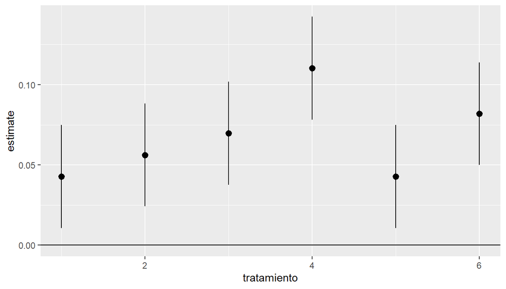

```r
a <- impact_eval(universo_f, endogenous_vars = c("total_purchases_after","transacted"),treatment = c("treat"))

alpha <- 0.01

ics <- mapply(function(x,y){
  ic <- c(x-qnorm(1-alpha/2)*y,x,x+qnorm(1-alpha/2)*y)
  return(ic)
},a[[2]][-1,]$estimate,a[[2]][-1,]$std.error)



ics <- data.frame(ics,row.names = c("lower","estimate","upper"))
ics <- rbind(tratamiento=1:6,ics)
ics <- as.data.frame(t(as.matrix(ics)))


ggplot(ics,aes(tratamiento,estimate))+
  geom_pointrange(aes(ymin=lower,ymax=upper))+
  geom_hline(yintercept = 0)
```

### 11. Repite el ejercicio sobre compras totales. Que resultados se aprecian? Que indica esto sobre la rentabilidad del sistema de incentivos?

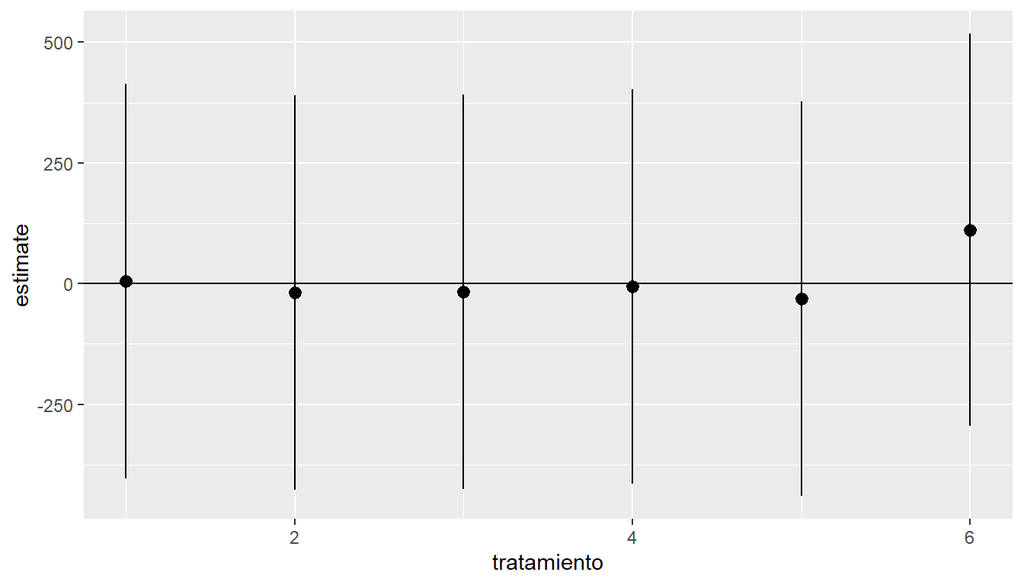

```r
alpha <- 0.05

ics11 <- mapply(function(x,y){
  ic <- c(x-qnorm(1-alpha/2)*y,x,x+qnorm(1-alpha/2)*y)
  return(ic)
},a[[1]][-1,]$estimate,a[[1]][-1,]$std.error)



ics <- data.frame(ics11,row.names = c("lower","estimate","upper"))
ics <- rbind(tratamiento=1:6,ics)
ics <- as.data.frame(t(as.matrix(ics)))


ggplot(ics,aes(tratamiento,estimate))+
  geom_pointrange(aes(ymin=lower,ymax=upper))+
  geom_hline(yintercept = 0)
```

### 12. Interpreta el impacto del gruop de referidos 4%. Porque el estimador es tan diferente y a la vez es no significativo? Por que esto no paso en la tasa de transaccionalidad?

Para el grupo de tratamiento 6 en ambas preguntas el ITT mide cosas distintas. En primer lugar, el ITT de `transacted` representa una probabilidad ya que la variable objetivo es una dummy, mientras que en la pregunta 11 se refiere al impacto en el gasto. Puede que la medida sea significativa para que las personas entren en la aplicación pero no para inducirlos a gastar.

### 13 (2ptos). Repite la medición en 11 pero ahora con `log(total_purchases_after+1)`. Que encuentras ahora? Interpreta las diferencias

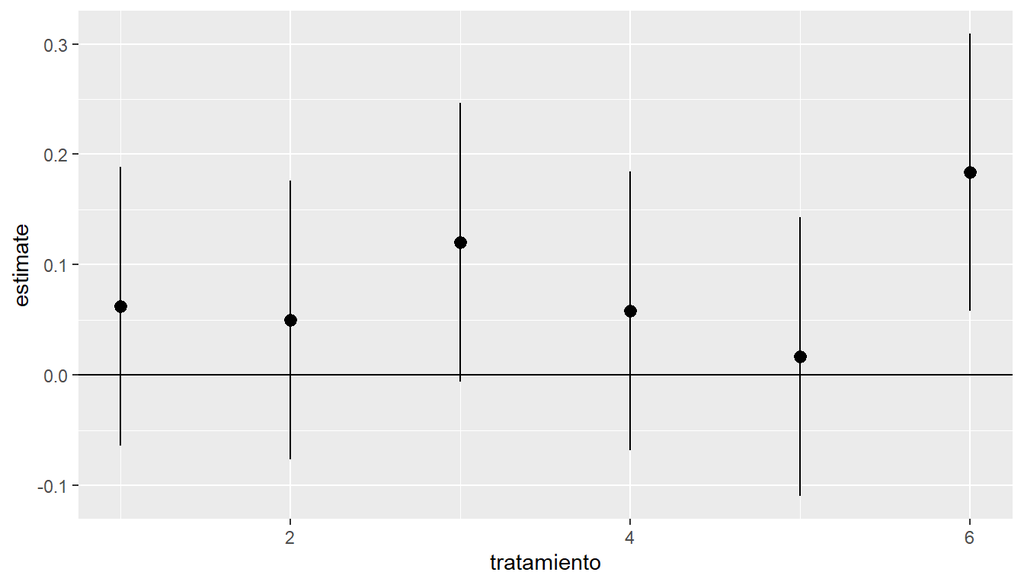

```r
a <- impact_eval(mutate(universo_f,"log(total_purchases_after+1)"=log(total_purchases_after+1)),
                 endogenous_vars = c("log(total_purchases_after+1)"),treatment = c("treat"))


alpha <- 0.05

ics11 <- mapply(function(x,y){
  ic <- c(x-qnorm(1-alpha/2)*y,x,x+qnorm(1-alpha/2)*y)
  return(ic)
},a[[1]][-1,]$estimate,a[[1]][-1,]$std.error)



ics <- data.frame(ics11,row.names = c("lower","estimate","upper"))
ics <- rbind(tratamiento=1:6,ics)
ics <- as.data.frame(t(as.matrix(ics)))


ggplot(ics,aes(tratamiento,estimate))+
  geom_pointrange(aes(ymin=lower,ymax=upper))+
  geom_hline(yintercept = 0)
```

Ahora el ITT el grupo de tratamiento 6 es significativo a diferencia de la pregunta anterior. En este caso el ITT representa el cambio porcentual en gasto de quienes reciben el tratamiento respecto a los que no. En ese sentido, el cambio puede deberse a dos cosas:

- que el impacto del tratamiento induce a quienes no gastaban nada a gastar muy poco, y ese impacto en niveles es poco significativo mientras que en porcentaje sí lo es.
- el logaritmo suaviza la distribución de gasto, lo que disminuye la varianza.

### 14 (4ptos). Describre que variables necesitas para hacer un análisis costo beneficio completo. Les doy algunas: Ticket promedio $100, Customer Lifetime value: $1,100. Con esto, que sistema de incentivos recomendarías? Porqué? Muestra el razonamiento detrás de tu recomendación

Para los tratamientos lump-sum (t1 y t2) que consisten en regalar cupones encontramos que el impacto en compras es estadísticamente igual a 0. Entonces el beneficio marginal, sin importar de cuánto sea el margen, es de 0. No es una buena estrategia entorno a las ganancias de la empresa ejecutar estos dos tratamientos.

Para el caso de los tratamientos 3 y 4 podemos utilizar alguna de las variables recomendadas y valorar cuanto gasta la empresa en la promoción y cuanto podría ganar respecto al comportamiento potencial de su cliente. Por ejemplo, con un ticket promedio de $100, el costo de las promociones sería en valor esperado $20 y $25 respectivamente. Por otro lado el beneficio de las promociones es igual a 0 ya que los resultados tampoco fueron significativos estadísticamente.

De acuerdo con algunas fuentes de Internet, el pocentaje de comisión de Rappi es aproximadamente de 20%.

Podemos asumir los percentiles de gasto en los tickets promedio por usuario y analizar a partir de qué punto los beneficios > costos. Por ejemplo, si asumimos que el primer decil tiene un ticket promedio aproximadamente de $60 entonces el costo es de 12 ó 15. Sin embargo el impacto sigue siendo igual a cero.

Para la estimación con logaritmo, puede ser que quienes no había hecho una compra y fueron inducidos a comprar son los que están jalando el impacto del tratamiento 6. Sin embargo, como sus compras son pequeñas, no jalan el nivel de compra. Entonces el mayor beneficio saldría al focalizar estos grupos.

El beneficio marginal naive sería customer_lifetime_value*margen+impacto*ticketpromedio*margen y el costo 0.04*ticketpromedio. Para tener una mejor estimacion necesitaríamos una forma de mapear a los referidos con quien los refirió.

Sería ideal tener información de cuántos referidos tuvo cada individuo (con su código de amigo) para calcular puntualmente qué porcentaje tuvo de descuento de las ventas totales. Además sería útil conocer si los invitados originados por el programa realizaron compras para calcular de mejor manera los beneficios del programa.

Dado que no tenemos esta información, realizamos los supuestos de que los tratados sólo invitaron a un amigo y calculamos los beneficios únicamente a través de las ventas de los individuos de la muestra (no con las de sus amigos). Quizá por esto salieron resultados poco rentables para Rappi.

### 15 (2ptos). Realiza la estimación de efectos heterogeneos para ambas variables usando `population`. Que encuentras? existe alguna subpoblación para la que los efectos difieran del promedio? Para cada efecto, muestra gráficas como lo hiciste en los ITTs

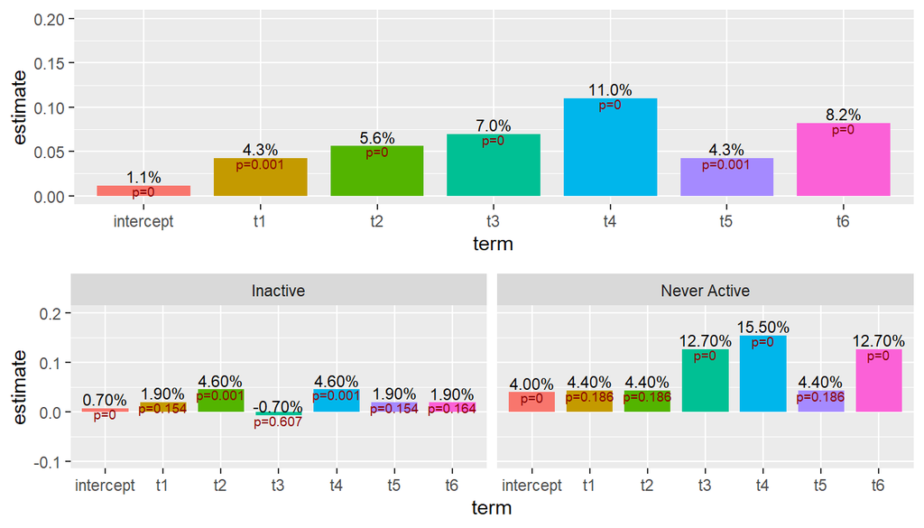

```r
a <- impact_eval(universo_f, endogenous_vars = c("total_purchases_after","transacted"),treatment = c("treat"),heterogenous_vars = c("population"))

ics15 <- mapply(function(x,y){

  ic <- c(x-qnorm(1-alpha/2)*y,x,x+qnorm(1-alpha/2)*y)
  return(ic)
},a[[1]][-1,]$estimate,a[[1]][-1,]$std.error)



ics <- data.frame(ics11,row.names = c("lower","estimate","upper"))
ics <- rbind(tratamiento=1:6,ics)
ics <- as.data.frame(t(as.matrix(ics)))


b <- ggplot(a[[2]],aes(y=estimate))+
  geom_bar(aes(x=term,fill=term),stat="identity",width = 0.8)+
  geom_text(aes(x=term,label=scales::percent(round(estimate,3)),vjust=-0.25),size=3)+
  scale_x_discrete(labels=c("intercept","t1","t2","t3","t4","t5","t6"))+
  theme(legend.position = "none")+
  geom_text(aes(x=term,label=paste0("p=",round(p.value,3)),vjust=1),size=2.5,color="red4")+
  ylim(0,0.2)


c <- ggplot(a[[4]],aes(y=estimate))+
  geom_bar(aes(x=term,fill=term),stat="identity",width = 0.8)+
  facet_wrap(~population)+
  geom_text(aes(x=term,label=scales::percent(round(estimate,3)),vjust=-0.25),size=3)+
  scale_x_discrete(labels=c("intercept","t1","t2","t3","t4","t5","t6"))+
  theme(legend.position = "none")+
  geom_text(aes(x=term,label=paste0("p=",round(p.value,3)),vjust=1),size=2.5,color="red4")+
  ylim(-0.1,0.2)


grid.arrange(b,c)
```

T3,T4 y T6 fueron muy diferentes al promedio y muy significativos para los usuarios nunca activos. En contraste, T3 y T4 tuvieron efecto muy por debajo del promedio para los usuarios inactivos. En general T2 y T5 no tuvieron efectos muy diferenciados.

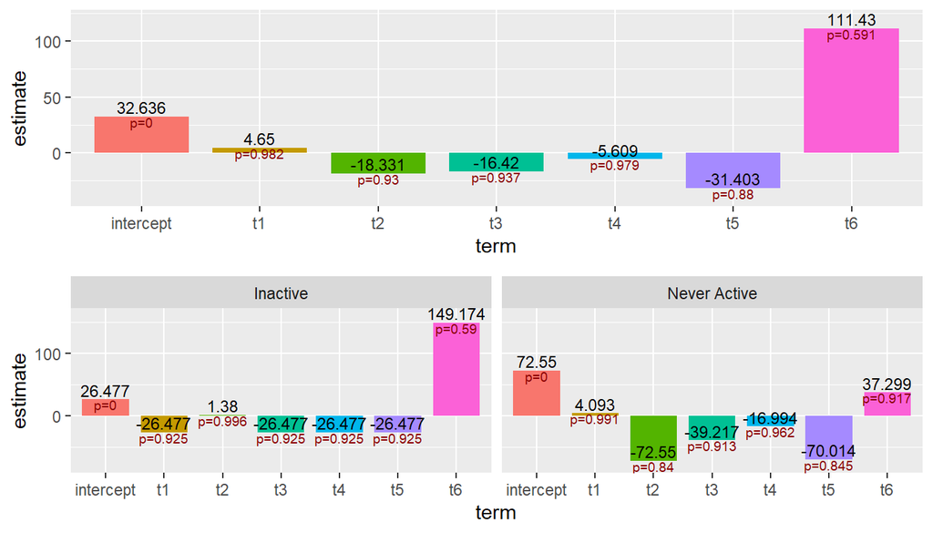

```r
d <- ggplot(a[[1]],aes(y=estimate))+
  geom_bar(aes(x=term,fill=term),stat="identity",width = 0.8)+
  geom_text(aes(x=term,label=round(estimate,3),vjust=-0.25),size=3)+
  scale_x_discrete(labels=c("intercept","t1","t2","t3","t4","t5","t6"))+
  theme(legend.position = "none")+
  geom_text(aes(x=term,label=paste0("p=",round(p.value,3)),vjust=1),size=2.5,color="red4")+
  ylim(-40,120)


e <- ggplot(a[[3]],aes(y=estimate))+
  geom_bar(aes(x=term,fill=term),stat="identity",width = 0.8)+
  facet_wrap(~population)+
  geom_text(aes(x=term,label=round(estimate,3),vjust=-0.25),size=3)+
  scale_x_discrete(labels=c("intercept","t1","t2","t3","t4","t5","t6"))+
  theme(legend.position = "none")+
  geom_text(aes(x=term,label=paste0("p=",round(p.value,3)),vjust=1),size=2.5,color="red4")+
  ylim(-80,160)

grid.arrange(d,e)
```

Ninguno de los tratamientos tuvo un efecto significativo en las compras de los usuarios, para ninguna de las subpoblaciones.

### 16 (2ptos). Repite el ejercicio para ``phone_verified`.

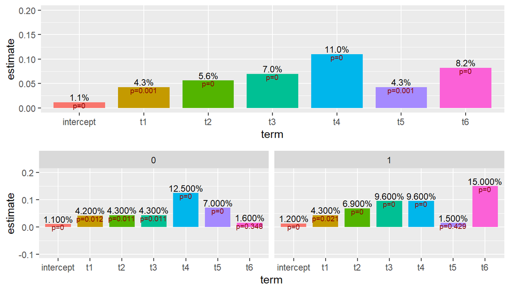

```r
a <- impact_eval(universo_f, endogenous_vars = c("total_purchases_after","transacted"),treatment = c("treat"),heterogenous_vars = c("phone_verified"))




b <- ggplot(a[[2]],aes(y=estimate))+
  geom_bar(aes(x=term,fill=term),stat="identity",width = 0.8)+
  geom_text(aes(x=term,label=scales::percent(round(estimate,3)),vjust=-0.25),size=3)+
  scale_x_discrete(labels=c("intercept","t1","t2","t3","t4","t5","t6"))+
  theme(legend.position = "none")+
  geom_text(aes(x=term,label=paste0("p=",round(p.value,3)),vjust=1),size=2.5,color="red4")+
  ylim(0,0.2)


c <- ggplot(a[[4]],aes(y=estimate))+
  geom_bar(aes(x=term,fill=term),stat="identity",width = 0.8)+
  facet_wrap(~phone_verified)+
  geom_text(aes(x=term,label=scales::percent(round(estimate,3)),vjust=-0.25),size=3)+
  scale_x_discrete(labels=c("intercept","t1","t2","t3","t4","t5","t6"))+
  theme(legend.position = "none")+
  geom_text(aes(x=term,label=paste0("p=",round(p.value,3)),vjust=1),size=2.5,color="red4")+
  ylim(-0.1,0.2)


grid.arrange(b,c)
```

T1 no tiene un impacto diferenciado entre subpoblaciones, entonces el impacto en las poblaciones es igual al impacto promedio. T4 es matyor para quienes no tienen el celular verificado respecto a quienes no lo tienen. T5 no es significativo para quienes sí tienen su teléfono verificado y para los que no tienen verificado el impacto es mucho más grande que el efecto promedio. T6 es muy significativo y potente para quienes sí tiene su teléfono verificado y mayor que el efecto promedio. T3 es ligeramente mayor al promedio para quienes tienen su teléfono verificado.

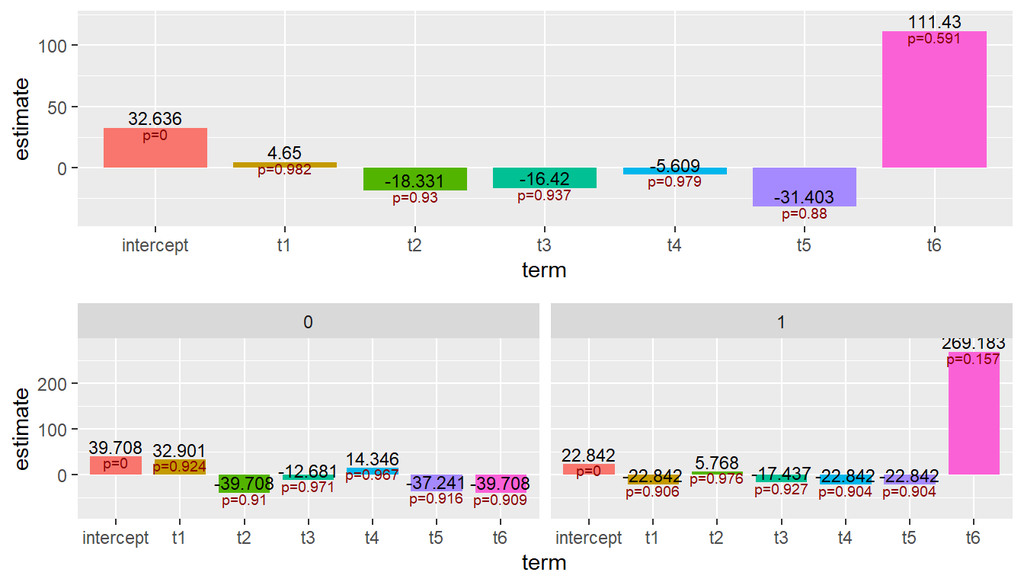

```r
d <- ggplot(a[[1]],aes(y=estimate))+
  geom_bar(aes(x=term,fill=term),stat="identity",width = 0.8)+
  geom_text(aes(x=term,label=round(estimate,3),vjust=-0.25),size=3)+
  scale_x_discrete(labels=c("intercept","t1","t2","t3","t4","t5","t6"))+
  theme(legend.position = "none")+
  geom_text(aes(x=term,label=paste0("p=",round(p.value,3)),vjust=1),size=2.5,color="red4")+
  ylim(-40,120)


e <- ggplot(a[[3]],aes(y=estimate))+
  geom_bar(aes(x=term,fill=term),stat="identity",width = 0.8)+
  facet_wrap(~phone_verified)+
  geom_text(aes(x=term,label=round(estimate,3),vjust=-0.25),size=3)+
  scale_x_discrete(labels=c("intercept","t1","t2","t3","t4","t5","t6"))+
  theme(legend.position = "none")+
  geom_text(aes(x=term,label=paste0("p=",round(p.value,3)),vjust=1),size=2.5,color="red4")+
  ylim(-80,280)

grid.arrange(d,e)
```

Ningún tratamiento tiene un efecto significativo en la población.

### 17. Presenta una propuesta de focalización con base en tus resultados generales y heterogeneos.

Nos dimos cuenta que T3,T4 y T6 deberían ser focalizadas para los usuarios nunca activos e inducirlos a entrar en la aplicación. Desafortunadamente, tanto en general como por subpoblión, los usuarios no respondieron signficativamente a los tratamientos para aumentar su gasto.

T5 debe ser focalizado en quienes no tienen su teléfono verificado. T2, T3, y T6 deben estar dirigidos a quienes tienen su teléfono verificado. Con esto se logrará que entren en la aplicación.